# Notebook - Visualización de datos y predicción M30 Madrid

Este notebook ha sido creado para el Trabajo de Fin de Máster de Carlos Jesús Peláez Rivas en Septiembre de 2018.

Los datos que se utilizarán en este notebook se han extraido de [este enlace](https://datos.madrid.es/portal/site/egob/menuitem.c05c1f754a33a9fbe4b2e4b284f1a5a0/?vgnextoid=33cb30c367e78410VgnVCM1000000b205a0aRCRD&vgnextchannel=374512b9ace9f310VgnVCM100000171f5a0aRCRD&vgnextfmt=default). Se trata de ficheros `csv`que contienen distintas columnas que ofrecen datos relativos al tráfico usando distintos sensores situados bajo la calzada. La descripción de los mismos puede encontrarse en [este enlace](https://datos.madrid.es/FWProjects/egob/Catalogo/Transporte/Trafico/ficheros/Estructura_DS_Contenido_Trafico_Historico.pdf)

Para este estudio se utilizan las columnas de carga de la vía (coches por hora en un intervalo de 15 minutos) y la velocidad medida de los mismos (también en un tramo de 15 minutos).

Los datos se han tratado para incluir en la base de datos únicamente los deseados. En este caso, se han seleccionado los datos relativos al sensor con id `1017` a las `8:00` de cada uno de los días disponibles en los históricos.

```python
from datetime import datetime
import matplotlib
import matplotlib.pyplot as plt
import numpy as np
import pandas as pd
import pymongo
import statsmodels.api as sm
from statsmodels.tsa.stattools import adfuller
from sklearn.metrics import mean_squared_error

%matplotlib inline
plt.style.use('classic')
```

### 1. Configuración

Se indica el sensor a estudiar y el rango de fechas para cargar los datos desde la base de datos MongoDB.

```python
# SELECT THE DESIRED ROAD SENSOR
sensor = 1017

## SELECT THE DESIRED DATES
start_date = datetime.strptime('01/09/2013 00:00', '%d/%m/%Y %H:%M')
end_date = datetime.strptime('31/12/2018 23:59', '%d/%m/%Y %H:%M')
```

### 2. Carga de datos

Se cargan los datos desde la base de datos MongoDB alojada en la misma máquina para el rango de fechas indicado.

```python
client = pymongo.MongoClient('localhost', 27017)

x = []
y = []
z = []

collection = client.tfm.history_m30
cursor = collection.find({f'$and': [{'code': sensor}, \
                                {'date': {'$gte': start_date, '$lte': end_date}}]}).sort("date", pymongo.ASCENDING)
for document in cursor:
    x.append(document['date'])
    y.append(document['properties']['intensity'])
    z.append(document['properties']['average_speed'])

client.close()

data = pd.DataFrame(
{'index' : np.linspace(1, len(x), len(x)),
 'date': x,
 'intensity': y,
 'average_speed': z
})
```

### 3. Visualización de los datos

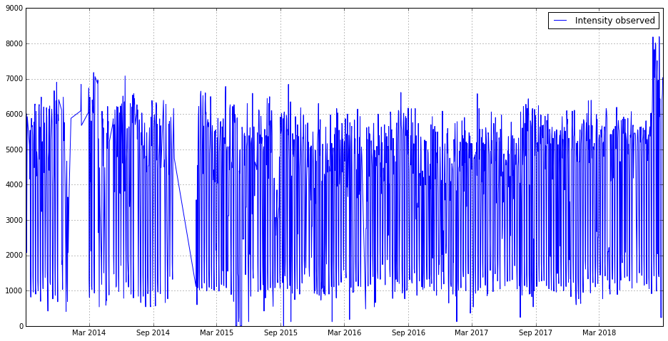

```python
plt.figure(figsize=(16, 8), facecolor='w', edgecolor='k')
plt.grid(True)
plt.plot(data['date'], data['intensity'], 'b-', label='Intensity observed')
plt.legend()
plt.show()
```

En la siguiente gráfica se muestran de nuevo los datos junto con la tendencia de los mismos usando una frecuencia de 365.

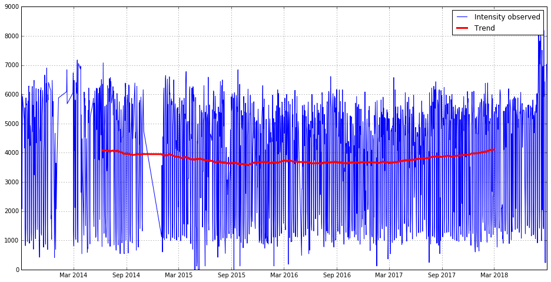

```python
descomposition = sm.tsa.seasonal_decompose(data['intensity'], model='additive', freq=365)

plt.figure(figsize=(16, 8), facecolor='w', edgecolor='k')
plt.grid(True)
plt.plot(data['date'], data['intensity'], label='Intensity observed')
plt.plot(data['date'], descomposition.trend, 'r-', lineWidth=3, label='Trend')
plt.legend()
plt.show()
```

### 4. Año 2017

En esta sección se muestran únicamente los datos de 2017.

```python
date1 = datetime.strptime('01/01/2017 00:00', '%d/%m/%Y %H:%M')
date2 = datetime.strptime('31/12/2017 23:59', '%d/%m/%Y %H:%M')

data_2017 = data[(data['date'] >= date1) & (data['date'] <= date2)]
```

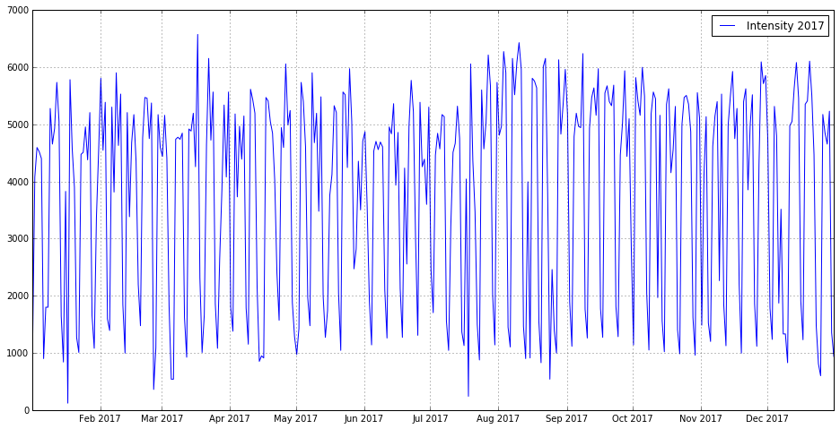

```python
plt.figure(figsize=(16, 8), facecolor='w', edgecolor='k')
plt.grid(True)
plt.plot(data_2017['date'], data_2017['intensity'], label='Intensity 2017')
plt.legend()
plt.show()
```

### 5. Marzo de 2017

En esta sección se muestran únicamente los datos de marzo de 2017.

```python
date1 = datetime.strptime('01/03/2017 00:00', '%d/%m/%Y %H:%M')
date2 = datetime.strptime('31/03/2017 23:59', '%d/%m/%Y %H:%M')

data_2017_3 = data[(data['date'] >= date1) & (data['date'] <= date2)]
```

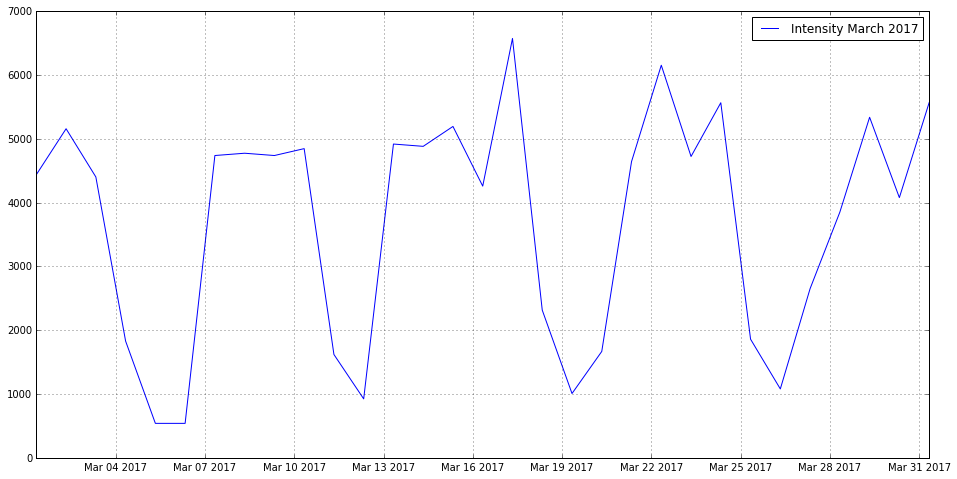

```python
plt.figure(figsize=(16, 8), facecolor='w', edgecolor='k')
plt.grid(True)
plt.plot(data_2017_3['date'], data_2017_3['intensity'], label='Intensity March 2017')
plt.legend()
plt.show()
```

La siguiente gráfica compara la intensidad de coches en la carretera con la velocidad media de los mismos. Como puede observarse son inversamente proporcionales entre ellas. A mayor carga de tráfico, menor velocidad media y viceversa.

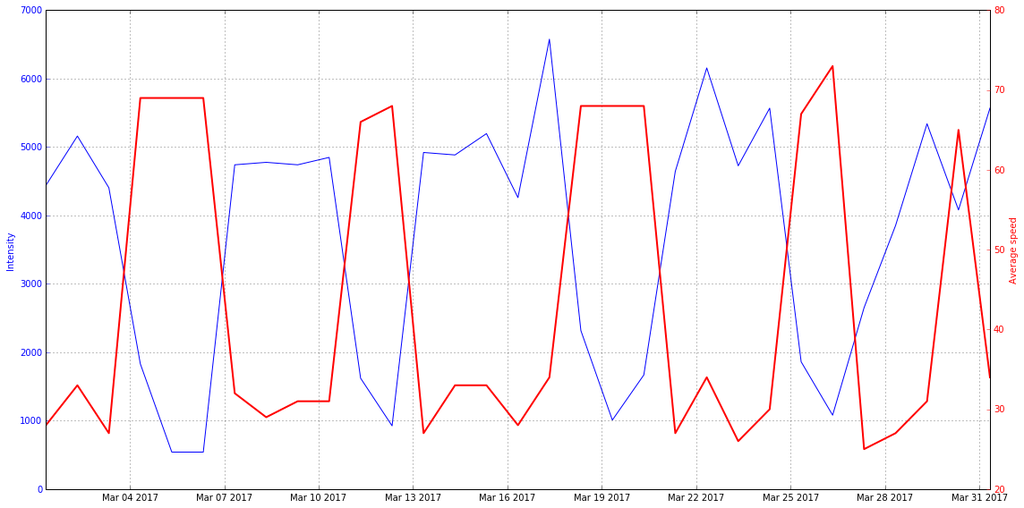

```python
fig, ax1 = plt.subplots(figsize=(16, 8))
plt.grid(True)
ax1.plot(data_2017_3['date'], data_2017_3['intensity'], 'b-')
ax1.set_ylabel('Intensity', color='b')
ax1.tick_params('y', colors='b')

ax2 = ax1.twinx()
ax2.plot(data_2017_3['date'], data_2017_3['average_speed'], 'r-', lineWidth=2)
ax2.set_ylabel('Average speed', color='r')
ax2.tick_params('y', colors='r')

fig.tight_layout()
plt.show()
```

### 6. Comparación de la intensidad de tráfico de Julio de 2017 con Septiembre de 2017

```python
date1 = datetime.strptime('01/7/2017 00:00', '%d/%m/%Y %H:%M')
date2 = datetime.strptime('31/7/2017 23:59', '%d/%m/%Y %H:%M')
data_2017_7 = data[(data['date'] >= date1) & (data['date'] <= date2)]

date1 = datetime.strptime('01/09/2017 00:00', '%d/%m/%Y %H:%M')
date2 = datetime.strptime('30/09/2017 23:59', '%d/%m/%Y %H:%M')
data_2017_9 = data[(data['date'] >= date1) & (data['date'] <= date2)]
```

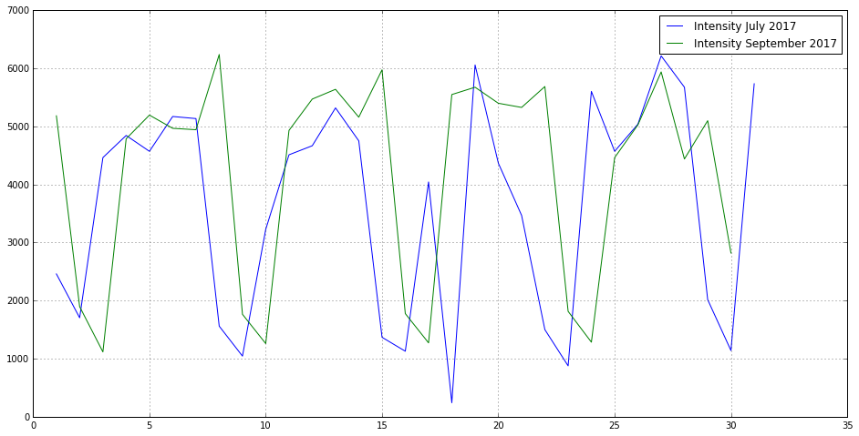

```python
indexes1 = np.linspace(1, len(data_2017_7['intensity']), len(data_2017_7['intensity']))
indexes2 = np.linspace(1, len(data_2017_9['intensity']), len(data_2017_9['intensity']))

plt.figure(figsize=(16, 8), facecolor='w', edgecolor='k')
plt.grid(True)
plt.plot(indexes1, data_2017_7['intensity'], label='Intensity July 2017')
plt.plot(indexes2, data_2017_9['intensity'], label='Intensity September 2017')
plt.legend()
plt.show()
```

### 7. Comparación de la intensidad de tráfico de Agosto de 2017 y Agosto de 2018

```python
date1 = datetime.strptime('01/08/2017 00:00', '%d/%m/%Y %H:%M')
date2 = datetime.strptime('31/08/2017 23:59', '%d/%m/%Y %H:%M')
data_2017_8 = data[(data['date'] >= date1) & (data['date'] <= date2)]

date1 = datetime.strptime('01/08/2018 00:00', '%d/%m/%Y %H:%M')
date2 = datetime.strptime('31/08/2018 23:59', '%d/%m/%Y %H:%M')
data_2018_8 = data[(data['date'] >= date1) & (data['date'] <= date2)]
```

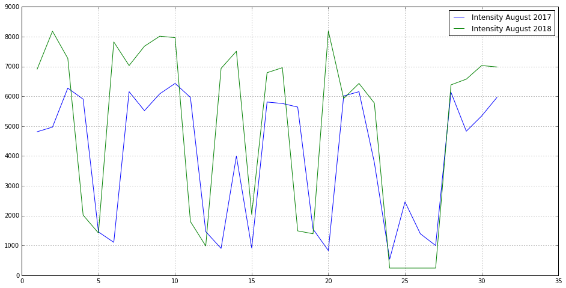

```python
indexes1 = np.linspace(1, len(data_2017_8['intensity']), len(data_2017_8['intensity']))
indexes2 = np.linspace(1, len(data_2018_8['intensity']), len(data_2018_8['intensity']))

plt.figure(figsize=(16, 8), facecolor='w', edgecolor='k')
plt.grid(True)
plt.plot(indexes1, data_2017_8['intensity'], label='Intensity August 2017')
plt.plot(indexes2, data_2018_8['intensity'], label='Intensity August 2018')
plt.legend()
plt.show()
```

### 9. Filtrado de todos los lunes y sábados para análisis posteriores

La serie temporal que se genera en este apartado, todos los lunes, será la elegida para realizar los siguentes estudios y predicciones.

```python
x = []
y = []
z = []

for i in range(len(data)):
    if data['date'][i].weekday() == 0:
        x.append(data['date'][i])
        y.append(data['intensity'][i])
        z.append(data['average_speed'][i])

data_mondays = pd.DataFrame(
{'index' : np.linspace(1, len(x), len(x)),
 'date': x,
 'intensity': y,
 'average_speed': z
})

x = []
y = []
z = []

for i in range(len(data)):
    if data['date'][i].weekday() == 5:
        x.append(data['date'][i])
        y.append(data['intensity'][i])
        z.append(data['average_speed'][i])

data_saturdays = pd.DataFrame(
{'index' : np.linspace(1, len(x), len(x)),
 'date': x,
 'intensity': y,
 'average_speed': z
})
```

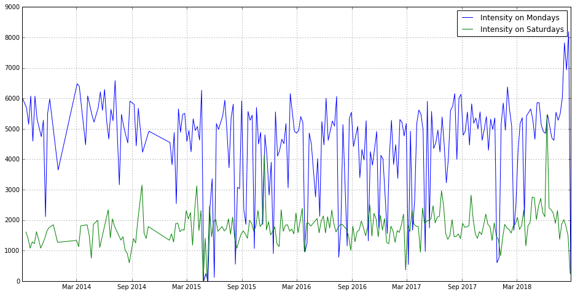

```python
plt.figure(figsize=(16, 8), facecolor='w', edgecolor='k')
plt.grid(True)
plt.plot(data_mondays['date'], data_mondays['intensity'], label='Intensity on Mondays')
plt.plot(data_saturdays['date'], data_saturdays['intensity'], label='Intensity on Saturdays')
plt.legend()
plt.show()
```

### 10. Descomposición de la serie temporal

```python
descomposition = sm.tsa.seasonal_decompose(data_mondays['intensity'], model='additive', freq=45)
```

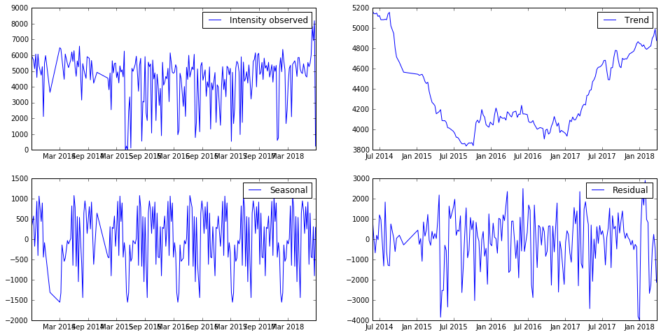

```python
plt.figure(figsize=(16, 8), facecolor='w', edgecolor='k')
plt.grid(True)

plt.subplot(221)
plt.plot(data_mondays['date'], data_mondays['intensity'], label='Intensity observed')
plt.legend()

plt.subplot(222)
plt.plot(data_mondays['date'], descomposition.trend, label='Trend')
plt.legend()

plt.subplot(223)
plt.plot(data_mondays['date'], descomposition.seasonal, label='Seasonal')
plt.legend()

plt.subplot(224)
plt.plot(data_mondays['date'], descomposition.resid, label='Residual')
plt.legend()

plt.show()
```

### 11. Estudio de la estacionalidad de los datos usando el test de Dickey-Fuller

```python
def testStationality(time_series, window, title):
    rolmean  = time_series.rolling(window=window, center=False).mean();
    rolstd = time_series.rolling(window=window, center=False).std();

    plt.figure(figsize=(16, 8), facecolor='w', edgecolor='k')
    plt.grid(True)
    plt.plot(time_series, label=title)
    plt.plot(rolmean, lineWidth=2, label='Rolling mean')
    plt.plot(rolstd, lineWidth=2, label='Rolling std')
    plt.legend(loc='best')
    plt.show()

    print ('Results of Dickey-Fuller Test:')
    dftest = adfuller(time_series, autolag='AIC')
    dfoutput = pd.Series(dftest[0:4], index=['Test Statistic','p-value','# Lags used','Number of observations used'])
    for key,value in dftest[4].items():
        dfoutput['Critical Value (%s)'%key] = value
    print (dfoutput)
```

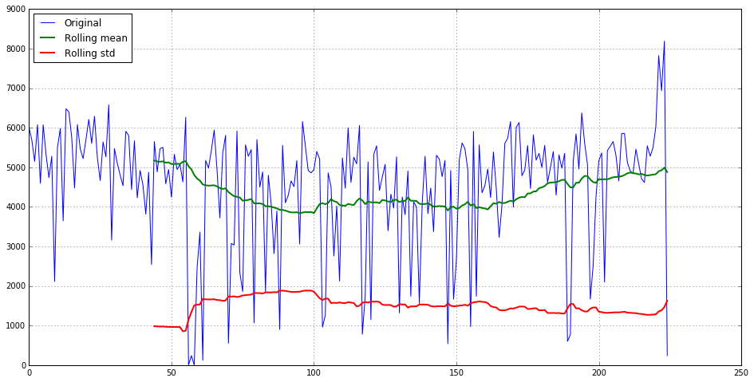

```
Results of Dickey-Fuller Test:
Test Statistic                -8.233884e+00
p-value                        5.961665e-13
# Lags used                    1.000000e+00
Number of observations used    2.230000e+02
Critical Value (1%)           -3.460019e+00
Critical Value (5%)           -2.874590e+00
Critical Value (10%)          -2.573725e+00
dtype: float64
```

```python
testStationality(data_mondays['intensity'].dropna(inplace=False), 45, 'Original')
```

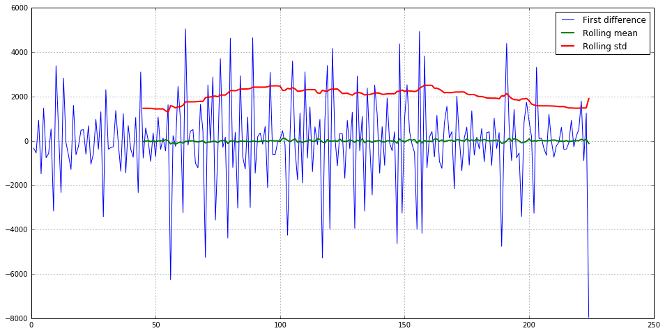

```
Results of Dickey-Fuller Test:
Test Statistic                -8.023310e+00
p-value                        2.048638e-12
# Lags used                    1.200000e+01
Number of observations used    2.110000e+02
Critical Value (1%)           -3.461727e+00
Critical Value (5%)           -2.875337e+00
Critical Value (10%)          -2.574124e+00
dtype: float64
```

```python
data_mondays['first_difference'] = data_mondays['intensity'] - data_mondays['intensity'].shift(1)
testStationality(data_mondays['first_difference'].dropna(inplace=False), 45, 'First difference')
```

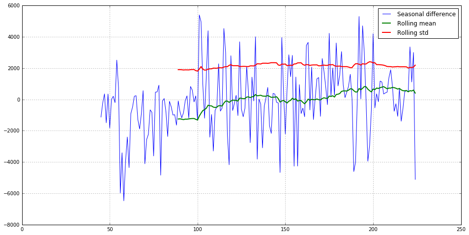

```
Results of Dickey-Fuller Test:
Test Statistic                  -5.207238
p-value                          0.000008
# Lags used                      3.000000
Number of observations used    176.000000
Critical Value (1%)             -3.468062
Critical Value (5%)             -2.878106
Critical Value (10%)            -2.575602
dtype: float64
```

```python
data_mondays['seasonal_difference'] = data_mondays['intensity'] - data_mondays['intensity'].shift(45)
testStationality(data_mondays['seasonal_difference'].dropna(inplace=False), 45, 'Seasonal difference')
```

### 12. Autocorrelación de los datos para comprobar la estacionalidad de la serie

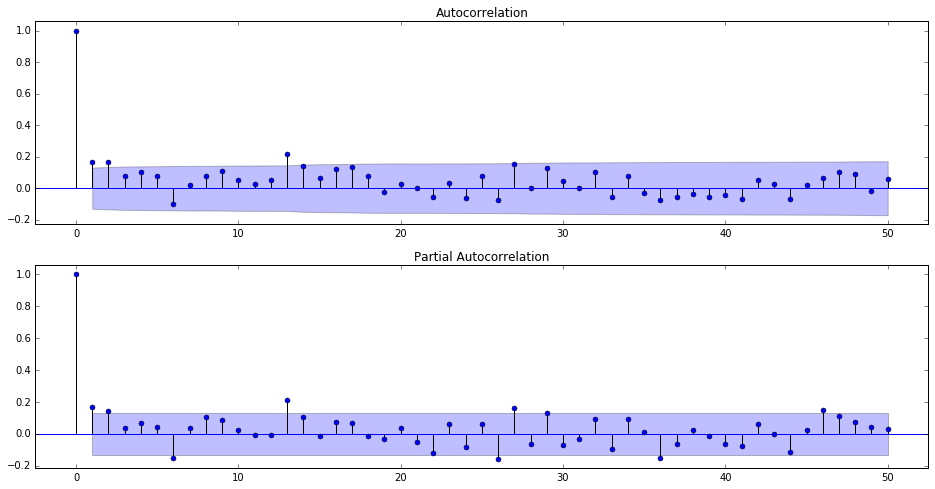

```python
fig = plt.figure(figsize=(16, 8), facecolor='w', edgecolor='k')
ax1 = fig.add_subplot(211)
fig = sm.graphics.tsa.plot_acf(data_mondays['intensity'], lags=50, alpha=.05, ax=ax1)
ax2 = fig.add_subplot(212)
fig = sm.graphics.tsa.plot_pacf(data_mondays['intensity'], lags=50, alpha=.05, ax=ax2)
```

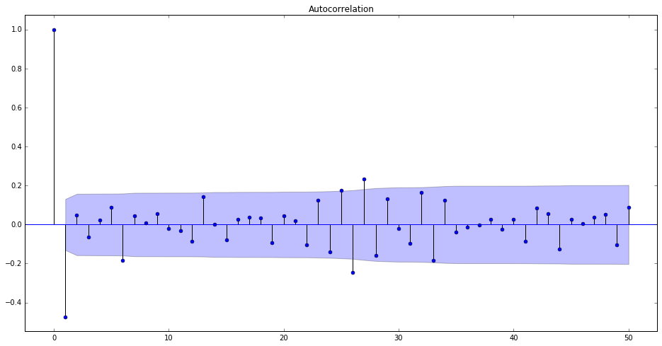

```python
fig = plt.figure(figsize=(16, 8), facecolor='w', edgecolor='k')
ax1 = fig.add_subplot(111)
fig = sm.graphics.tsa.plot_acf(data_mondays['first_difference'][1:], lags=50, alpha=.05, ax=ax1)
```

### 13. Análisis por fuerza bruta de índices para el modelo SARIMA

```python
def evaluate_sarima_model(X, sarima_order, sarima_seasonal_order):
    history = [x for x in X]

    train_index = int(len(history) - 5)
    train, test = history[0:train_index], history[train_index:]

    # make predictions
    predictions = list()
    for t in range(len(test)):
        model = sm.tsa.statespace.SARIMAX(train, trend='n', order=sarima_order, seasonal_order=sarima_seasonal_order)
        model_fit = model.fit()
        forecast = model_fit.forecast()
        predictions.append(forecast)
        train.append(test[t])

    error = mean_squared_error(test, predictions)

    return error
```

```python
p_values = [0, 1]
d_values = [0, 1]
q_values = [1, 2]

P_values = [0, 1]
D_values = [1]
Q_values = [1]
s_values = [4, 7, 12]

mse_indexes = []
mse_values = []

best_score, best_order, best_seasonal_order = float("inf"), None, None
for p in p_values:
    for d in d_values:
        for q in q_values:
            for P in P_values:
                for D in D_values:
                    for Q in Q_values:
                        for s in s_values:
                            order = (p, d, q)
                            seasonal_order = (P, D, Q, s)
                            try:
                                mse = evaluate_sarima_model(data_mondays['intensity'], order, seasonal_order)

                                mse_indexes.append(str(p) + str(d) + str(q) + str(P) + str(D) + str(Q) + str(s))
                                mse_values.append(mse)

                                if mse < best_score:
                                    best_score, best_order, best_seasonal_order = mse, order, seasonal_order
                                print('SARIMA %s %s MSE=%.3f' % (order, seasonal_order, mse))
                            except Exception as e:
                                print(e)
                                continue

print('Best SARIMA %s %s MSE=%.3f' % (best_order, best_seasonal_order, best_score))

# Out:
# SARIMA (0, 0, 1) (0, 1, 1, 4) MSE=11459504.805
# SARIMA (0, 0, 1) (0, 1, 1, 7) MSE=10035366.550
# SARIMA (0, 0, 1) (0, 1, 1, 12) MSE=10525447.447
# SARIMA (0, 0, 1) (1, 1, 1, 4) MSE=10682349.428
# SARIMA (0, 0, 1) (1, 1, 1, 7) MSE=10091929.288
# SARIMA (0, 0, 1) (1, 1, 1, 12) MSE=10361811.722
# SARIMA (0, 0, 2) (0, 1, 1, 4) MSE=11083164.392
# SARIMA (0, 0, 2) (0, 1, 1, 7) MSE=9577653.472
# SARIMA (0, 0, 2) (0, 1, 1, 12) MSE=10020148.239
# SARIMA (0, 0, 2) (1, 1, 1, 4) MSE=10586298.209
# SARIMA (0, 0, 2) (1, 1, 1, 7) MSE=9608449.631
# SARIMA (0, 0, 2) (1, 1, 1, 12) MSE=9980740.754
# SARIMA (0, 1, 1) (0, 1, 1, 4) MSE=10731266.338
# SARIMA (0, 1, 1) (0, 1, 1, 7) MSE=9951882.030
# SARIMA (0, 1, 1) (0, 1, 1, 12) MSE=10931277.665
# SARIMA (0, 1, 1) (1, 1, 1, 4) MSE=10725485.120
# SARIMA (0, 1, 1) (1, 1, 1, 7) MSE=9821800.293
# SARIMA (0, 1, 1) (1, 1, 1, 12) MSE=10871159.751
# SARIMA (0, 1, 2) (0, 1, 1, 4) MSE=10728328.677
# SARIMA (0, 1, 2) (0, 1, 1, 7) MSE=10779438.995
# SARIMA (0, 1, 2) (0, 1, 1, 12) MSE=10042195.158
# SARIMA (0, 1, 2) (1, 1, 1, 4) MSE=10714222.096
# SARIMA (0, 1, 2) (1, 1, 1, 7) MSE=9848322.599
# SARIMA (0, 1, 2) (1, 1, 1, 12) MSE=10635462.582
# SARIMA (1, 0, 1) (0, 1, 1, 4) MSE=12107736.957
# SARIMA (1, 0, 1) (0, 1, 1, 7) MSE=9878782.229
# SARIMA (1, 0, 1) (0, 1, 1, 12) MSE=9904036.333
# SARIMA (1, 0, 1) (1, 1, 1, 4) MSE=11291291.816
# SARIMA (1, 0, 1) (1, 1, 1, 7) MSE=7830409.639
# SARIMA (1, 0, 1) (1, 1, 1, 12) MSE=9971369.286
# SARIMA (1, 0, 2) (0, 1, 1, 4) MSE=11037264.057
# SARIMA (1, 0, 2) (0, 1, 1, 7) MSE=10108912.279
# SARIMA (1, 0, 2) (0, 1, 1, 12) MSE=9981286.081
# SARIMA (1, 0, 2) (1, 1, 1, 4) MSE=10955432.367
# SARIMA (1, 0, 2) (1, 1, 1, 7) MSE=9724897.654
# SARIMA (1, 0, 2) (1, 1, 1, 12) MSE=10108314.965
# SARIMA (1, 1, 1) (0, 1, 1, 4) MSE=11191191.644
# SARIMA (1, 1, 1) (0, 1, 1, 7) MSE=10754160.369
# SARIMA (1, 1, 1) (0, 1, 1, 12) MSE=10922535.477
# SARIMA (1, 1, 1) (1, 1, 1, 4) MSE=10728368.721
# SARIMA (1, 1, 1) (1, 1, 1, 7) MSE=9858233.280
# SARIMA (1, 1, 1) (1, 1, 1, 12) MSE=9709065.018
# SARIMA (1, 1, 2) (0, 1, 1, 4) MSE=11516238.449
# SARIMA (1, 1, 2) (0, 1, 1, 7) MSE=9680250.934
# SARIMA (1, 1, 2) (1, 1, 1, 4) MSE=10992800.660
# SARIMA (1, 1, 2) (1, 1, 1, 7) MSE=8030553.873
# Best SARIMA (1, 0, 1) (1, 1, 1, 7) MSE=7830409.639
```

Mostrar los errores graficamente para poder ver la evolución y comprobar qué índices ofrecen el mejor resultado.

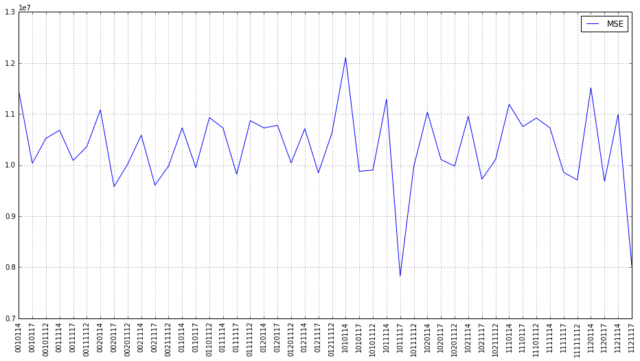

```python
plt.figure(figsize=(16, 8), facecolor='w', edgecolor='k')
plt.grid(True)
plt.plot(mse_indexes, mse_values, label='MSE')
plt.xticks(mse_indexes, rotation='vertical')
plt.legend()
plt.show()
```

### 14. Predicción de datos usando el modelo SARIMA

Para esta predicción se usará el mejor resultado que se ha obtenido en el paso anterior.

```python
size = data_mondays.shape[0]
number_of_predictions = 25
future_indexes = np.linspace(size + 1, size + number_of_predictions, number_of_predictions)

for index in future_indexes:
    s = pd.Series(index, index=['index'])
    data_mondays = data_mondays.append(s, ignore_index=True)
```

```python
model = sm.tsa.statespace.SARIMAX(data_mondays['intensity'], trend='n', order=(1, 0, 1), seasonal_order=(1 ,1, 1, 7))
model_fit = model.fit(maxiter=200)

sarima_fitted = model_fit.fittedvalues
sarima_forecast = results.predict(start = 200, end= 225, dynamic= True)
sarima_forecast_future = results.predict(start = 226, end= 250, dynamic= True)
```

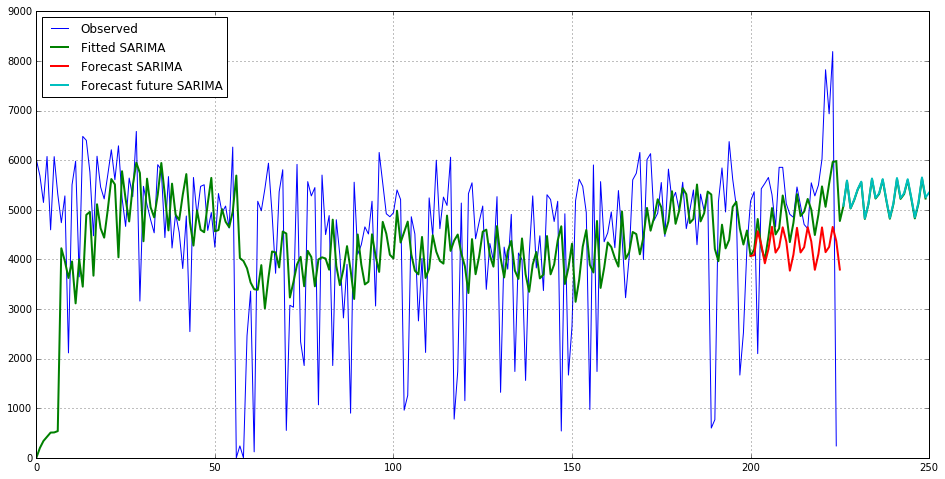

```python
plt.figure(figsize=(16, 8), facecolor='w', edgecolor='k')
plt.grid(True)
plt.plot(data_mondays['intensity'], label='Observed')
plt.plot(sarima_fitted, lineWidth=2, label='Fitted SARIMA')
plt.plot(sarima_forecast, lineWidth=2, label='Forecast SARIMA')
plt.plot(sarima_forecast_future, lineWidth=2, label='Forecast future SARIMA')
plt.legend(loc='best')
plt.show()
```